# Directed Acyclic Graphs (DAGs) in R

Workplace physical and social factors on low back pain

Kenta Okuyama

mars 04, 2026

## Agenda (40 min)

- Why DAGs in epidemiology (5 min)
- Study example (5 min): workplace physical and social factors → low back pain (Tamekuni et al. 2026)
- Hands-on: build a DAG in R (25-30 min)
- Q&A

## Why DAGs?

DAGs help you:

- make causal assumptions explicit
- identify confounders
- decide what to (and what not to) adjust for
- communicate analysis decisions transparently

Core references for causal diagrams in epidemiology: (Greenland, Pearl, and Robins 1999; Shrier and Platt 2008; Hernán and Robins 2020)

## Key terms

- Confounder: common cause of exposure & outcome
- Mediator: lies on the causal pathway
- Collider: common effect of two variables
- Effect modifier: modify the effect of exposure on outcome
- Adjustment rules (for total effect):
  - adjust confounders
  - avoid adjusting mediators
  - avoid adjusting/conditioning on colliders

(Greenland, Pearl, and Robins 1999; Hernán and Robins 2020)

## Why not “adjust for everything”?

Adjusting for “all measured variables” can:

- block causal effect components (mediators)
- open biasing paths (colliders)
- reduce precision

(Shrier and Platt 2008; Greenland, Pearl, and Robins 1999)

## Example paper

We use a published occupational health study as an example to ground variable choices and modeling style:

- Japanese workers at small/medium sized enterprises, cross-sectional survey
- Workplace physical and social factors: physical load, interpersonal relations stress
- Low back pain (we skip the category acute/chronic pain for simplicity)

(Tamekuni et al. 2026)

## Background and our hypothesis

- Previous studies on occupational pain investigated physical and social factors but without causal structure
- High physical load → Chronic low back pain
- Good interpersonal relations at work may mitigate the association

## Variables

- Physical load (exposure)
- Low back pain (outcome)
- Age, Gender, Education, Smoking, Drinking, BMI, Work hours, Job statisfaction, Depression, Interpersonal relations stress (confounders/mediators/effect modifiers)

## Start with exposure → outcome

```r
# 1. Name and position variables in a x-y dimension (physical load = p_load, low back pain = lbp)
coords1 <- list(
  x = c(p_load = 1, lbp = 3),
  y = c(p_load = 0, lbp = 0)
)

# 2. Define casual structures
g1 <- dagify(
  lbp ~ p_load,

  # set position of variables
  coords = coords1,

  # label variables
  labels = c(
    "lbp" = "LB pain",
    "p_load" = "Physical\n load"
    ),

  # define exposure and outcome
  exposure = "p_load",
  outcome = "lbp"
)
```

## DAG 1

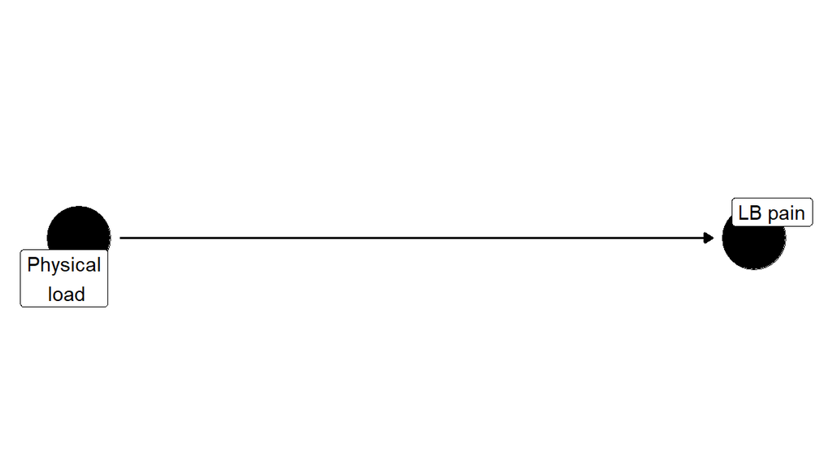

```r
ggdag(g1, text = FALSE, use_labels = "label") +
  theme_dag()
```

## Add socio-demographic factors

```r
# 1. Name and position variables in a x-y dimension
coords2 <- list(
  x = c(age = -2.5, gender = -2.5, education = -2, income = -2, p_load = 1, lbp = 3),
  y = c(age = 0, gender = -0.5, education = 0.5, income = 1, p_load = 0, lbp = 0)
)

# 2. Define casual structures
g2 <- dagify(
  lbp ~ p_load + age + gender + education + income,
  p_load ~ age + gender + education,
  education ~ gender,
  income ~ age + gender + education,
  coords = coords2,
  labels = c(
    "lbp" = "LB pain",
    "p_load" = "Physical\n load",
    "age" = "Age",
    "gender" = "Gender",
    "education" = "Education",
    "income" = "Income"
  ),
  exposure = "p_load",
  outcome = "lbp"
  # latent = "pa_b"
)
```

## DAG 2

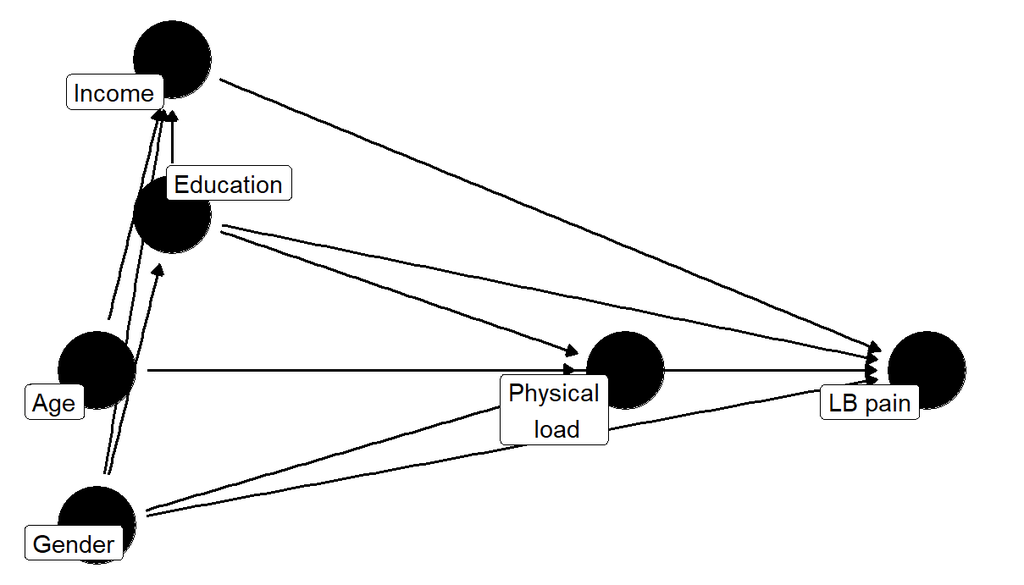

```r
ggdag(g2, text = FALSE, use_labels = "label") +
  theme_dag()
```

## Add lifestyle factors

```r
# 1. Name and position variables in a x-y dimension
coords3 <- list(
  x = c(age = -2, gender = -2, education = -2, income = -2, drink = -1, smoke = -1, sleep = -1, pa = -1, p_load = 1, lbp = 3),
  y = c(age = 0, gender = -0.5, education = 0.5, income = 1, drink = 1, smoke = 0.5, sleep = -0.5, pa = -1, p_load = 0, lbp = 0)
)

# 2. Define causal structures
g3 <- dagify(
  lbp ~ p_load + age + gender + education + income + drink + smoke + sleep + pa,
  p_load ~ age + gender + education,
  education ~ gender,
  income ~ age + gender + education,
  drink ~ age + gender + education + income + pa,
  smoke ~ age + gender + education + income + pa,
  sleep ~  age + gender + drink + smoke + pa + p_load + lbp,
  pa ~ age + gender + drink + smoke + sleep + p_load + lbp,

  coords = coords3,
  labels = c(
    "lbp" = "LB pain",
    "p_load" = "Physical\n load",
    "age" = "Age",
    "gender" = "Gender",
    "education" = "Education",
    "drink" = "Drinking",
    "smoke" = "Smoking",
    "sleep" = "Sleep\n quality",
    "pa" = "Physical\n activity",
    "income" = "Income"
  ),
  exposure = "p_load",
  outcome = "lbp"

)
```

## DAG 3

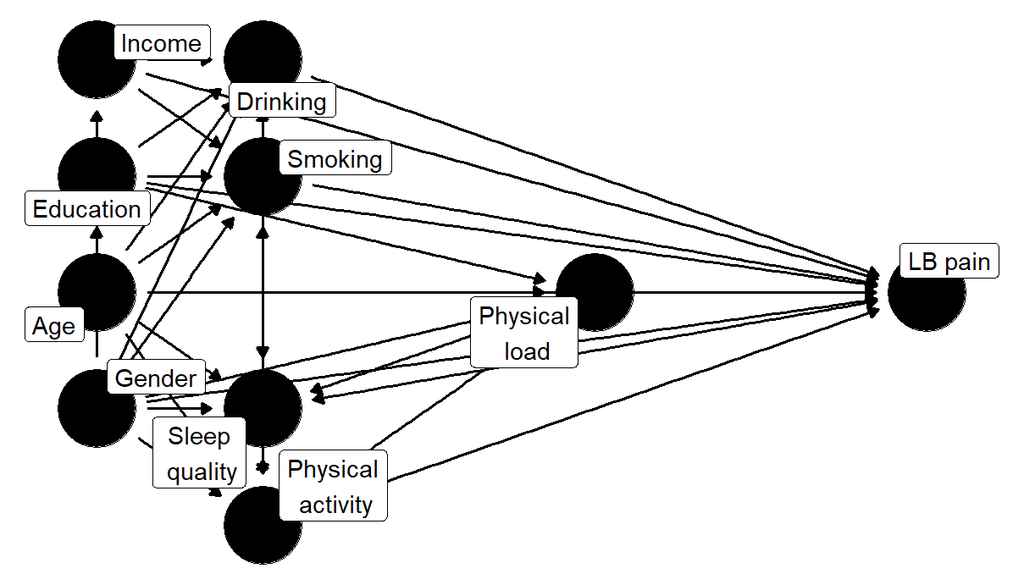

```r
ggdag(g3, text = FALSE, use_labels = "label") +
  theme_dag()
```

## Step 3: Introduce PhysicalLoad as a potential effect modifier

We now ask:

Does interpersonal stress have a different effect on chronic LBP when physical load is high vs low?

Effect modification is a modeling/interpretation question; DAGs mainly help with confounding control. (Hernán and Robins 2020)

But we still must decide: is PhysicalLoad also a confounder?

We’ll show two defensible options.

## Option A: PhysicalLoad is an effect modifier only (not a confounder)

Assumption:

- Physical load affects chronic LBP,
- but does not cause interpersonal relations stress (after accounting for job type, etc.)

## Option A: PhysicalLoad is an effect modifier only (not a confounder)

```r
dag3A <- dagitty("dag {
  InterpersonalStress -> LBP_Chronic
  InterpersonalStress -> MentalHealth -> LBP_Chronic

  PhysicalLoad -> LBP_Chronic

  Age -> InterpersonalStress
  Age -> MentalHealth
  Age -> LBP_Chronic
  Age -> PhysicalLoad

  Sex -> InterpersonalStress
  Sex -> MentalHealth
  Sex -> LBP_Chronic
  Sex -> PhysicalLoad

  JobType -> InterpersonalStress
  JobType -> LBP_Chronic
  JobType -> PhysicalLoad

  WorkHours -> InterpersonalStress
  WorkHours -> MentalHealth
  WorkHours -> LBP_Chronic

  PriorLBP -> InterpersonalStress
  PriorLBP -> LBP_Chronic
}")
```

## Option A: PhysicalLoad is an effect modifier only (not a confounder)

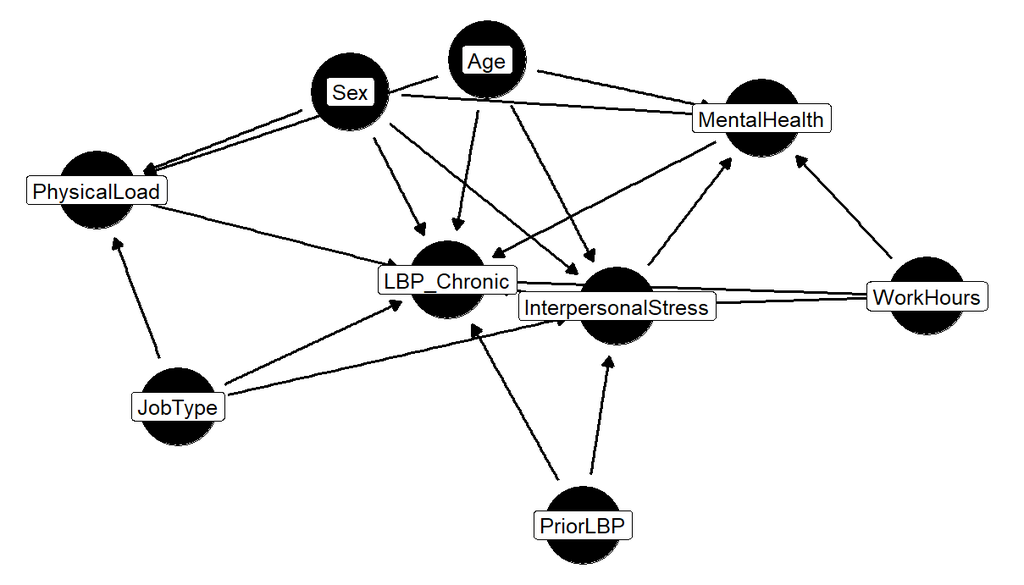

```r
ggdag(dag3A, layout = "stress") +
  geom_dag_edges() +
  geom_dag_label(size = 3.3) +
  theme_dag()
```

## Option B: PhysicalLoad is both a confounder and effect modifier

Assumption: - Physical load influences interpersonal stress (e.g., demanding physical roles affect teamwork/strain), - and also affects chronic LBP.

## Option B: PhysicalLoad is both a confounder and effect modifier

```r
dag3B <- dagitty("dag {
  InterpersonalStress -> LBP_Chronic
  InterpersonalStress -> MentalHealth -> LBP_Chronic

  PhysicalLoad -> InterpersonalStress
  PhysicalLoad -> LBP_Chronic

  Age -> InterpersonalStress
  Age -> MentalHealth
  Age -> LBP_Chronic
  Age -> PhysicalLoad

  Sex -> InterpersonalStress
  Sex -> MentalHealth
  Sex -> LBP_Chronic
  Sex -> PhysicalLoad

  JobType -> InterpersonalStress
  JobType -> LBP_Chronic
  JobType -> PhysicalLoad

  WorkHours -> InterpersonalStress
  WorkHours -> MentalHealth
  WorkHours -> LBP_Chronic

  PriorLBP -> InterpersonalStress
  PriorLBP -> LBP_Chronic
}")
```

## Option B: PhysicalLoad is both a confounder and effect modifier

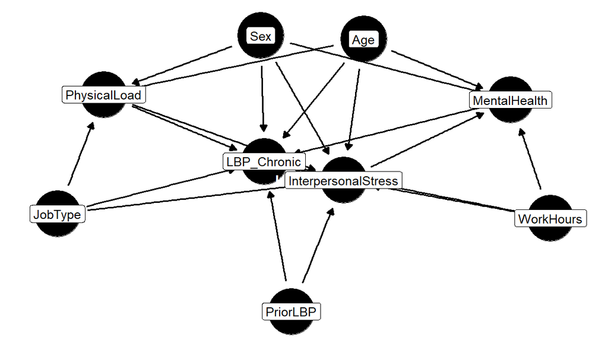

```r
ggdag(dag3B, layout = "stress") +
  geom_dag_edges() +
  geom_dag_label(size = 3.3) +
  theme_dag()
```

## Compute minimal adjustment sets (Option A)

```r
adjustmentSets(dag3A, exposure = "InterpersonalStress", outcome = "LBP_Chronic")
```

```
## { Age, JobType, PriorLBP, Sex, WorkHours }
```

Interpretation:

- Under Option A, physical load may not be required for confounding control.
- You can still include it to test effect modification.

dagitty reference: (Textor et al. 2016)

## Compute minimal adjustment sets (Option B)

```r
adjustmentSets(dag3B, exposure = "InterpersonalStress", outcome = "LBP_Chronic")
```

```
## { Age, JobType, PhysicalLoad, PriorLBP, Sex, WorkHours }
```

Interpretation:

- Under Option B, physical load is part of confounding control and can be used for effect modification.

## Practical decision slide (what you say)

- Pick one DAG that matches your substantive belief.
- Choose one feasible adjustment set.
- Explain why you did not adjust for:
  - MentalHealth (mediator) if total effect
  - any selection variables / colliders (if applicable)

(Greenland, Pearl, and Robins 1999; Shrier and Platt 2008; Hernán and Robins 2020)

## Paper-style modeling approach (illustrative)

Your paper used multinomial logistic regression for none / acute / chronic. (Tamekuni et al. 2026)

- baseline adjustment (choose based on your DAG)
- effect modification test via interaction term

## How to present effect modification (cleanly)

Instead of only reporting an interaction p-value, show predicted chronic LBP probabilities (or ORs) across interpersonal stress, by physical load strata.

(Once you know your variable coding, you can add a plot chunk here.)

## Take-home points

- DAGs make causal assumptions explicit and improve adjustment decisions. (Greenland, Pearl, and Robins 1999)
- Separate confounders vs mediators vs colliders to avoid bias. (Shrier and Platt 2008; Hernán and Robins 2020)
- dagitty makes the “why we adjusted for X” reproducible. (Textor et al. 2016)
- Physical load can be:
  - effect modifier only (Option A), or
  - both confounder and effect modifier (Option B)

## References

Greenland, Sander, Judea Pearl, and James M. Robins. 1999. “Causal Diagrams for Epidemiologic Research.” *Epidemiology* 10 (1): 37–48. https://doi.org/10.1097/00001648-199901000-00008.

Hernán, Miguel A., and James M. Robins. 2020. *Causal Inference: What If*. Boca Raton: Chapman & Hall/CRC.

Shrier, Ian, and Robert W. Platt. 2008. “Reducing Bias Through Directed Acyclic Graphs.” *BMC Medical Research Methodology* 8: 70. https://doi.org/10.1186/1471-2288-8-70.

Tamekuni, Yurika, Kenta Okuyama, Atsushi Motohiro, Daijo Shiratsuchi, et al. 2026. “Physical and Social Factors Differentiating Acute and Chronic Low Back Pain Among Small- and Medium-Sized Enterprise Workers in Japan: A Cross-Sectional Study.” *European Journal of Investigation in Health, Psychology and Education* 16 (2): 17. https://doi.org/10.3390/ejihpe16020017.

Textor, Johannes, Benito van der Zander, Mark S. Gilthorpe, Maciej Liśkiewicz, and George T. H. Ellison. 2016. “Robust Causal Inference Using Directed Acyclic Graphs: The R Package ’Dagitty’.” *International Journal of Epidemiology* 45 (6): 1887–94. https://doi.org/10.1093/ije/dyw341.